# Red Wine Quality Exploration By Francis Samkoh

#### Brief Introduction

This dataset is publicly available for research. The details are described in [Cortez et al., 2009]

This dataset was created, using red wine samples. The inputs include objective tests (e.g. PH values) and the output is based on sensory data (median of at least 3 evaluations made by wine experts). Each expert graded the wine quality between 0 (very bad) and 10 (very excellent). The dataset is a tidy data with no missing attribute values

I want to take a look at some statisticsabout the data

#### Taking a look at the first 6 observations of the data

```
##   X fixed.acidity volatile.acidity citric.acid residual.sugar chlorides
## 1 1           7.4             0.70        0.00            1.9     0.076
## 2 2           7.8             0.88        0.00            2.6     0.098
## 3 3           7.8             0.76        0.04            2.3     0.092
## 4 4          11.2             0.28        0.56            1.9     0.075
## 5 5           7.4             0.70        0.00            1.9     0.076
## 6 6           7.4             0.66        0.00            1.8     0.075
##   free.sulfur.dioxide total.sulfur.dioxide density   pH sulphates alcohol
## 1                  11                   34  0.9978 3.51      0.56     9.4
## 2                  25                   67  0.9968 3.20      0.68     9.8
## 3                  15                   54  0.9970 3.26      0.65     9.8
## 4                  17                   60  0.9980 3.16      0.58     9.8
## 5                  11                   34  0.9978 3.51      0.56     9.4
## 6                  13                   40  0.9978 3.51      0.56     9.4
##   quality
## 1       5
## 2       5
## 3       5
## 4       6
## 5       5
## 6       5
```

#### Checking number of observations and variables respectively.

```
## [1] 1599   13
```

The Red Wine dataset contains 1599 observations on 13 variables of the wine.

#### Checking structure of data

```
## 'data.frame':    1599 obs. of  13 variables:
##  $ X                   : int  1 2 3 4 5 6 7 8 9 10 ...
##  $ fixed.acidity       : num  7.4 7.8 7.8 11.2 7.4 7.4 7.9 7.3 7.8 7.5 ...
##  $ volatile.acidity    : num  0.7 0.88 0.76 0.28 0.7 0.66 0.6 0.65 0.58 0.5 ...
##  $ citric.acid         : num  0 0 0.04 0.56 0 0 0.06 0 0.02 0.36 ...
##  $ residual.sugar      : num  1.9 2.6 2.3 1.9 1.9 1.8 1.6 1.2 2 6.1 ...
##  $ chlorides           : num  0.076 0.098 0.092 0.075 0.076 0.075 0.069 0.065 0.073 0.071 ...
##  $ free.sulfur.dioxide : num  11 25 15 17 11 13 15 15 9 17 ...
##  $ total.sulfur.dioxide: num  34 67 54 60 34 40 59 21 18 102 ...
##  $ density             : num  0.998 0.997 0.997 0.998 0.998 ...
##  $ pH                  : num  3.51 3.2 3.26 3.16 3.51 3.51 3.3 3.39 3.36 3.35 ...
##  $ sulphates           : num  0.56 0.68 0.65 0.58 0.56 0.56 0.46 0.47 0.57 0.8 ...
##  $ alcohol             : num  9.4 9.8 9.8 9.8 9.4 9.4 9.4 10 9.5 10.5 ...
##  $ quality             : int  5 5 5 6 5 5 5 7 7 5 ...
```

These variables all have numeric values except for “X” and “quality” which have intergers values.

#### Checking names of Variables

```
##  [1] "X"                    "fixed.acidity"        "volatile.acidity"
##  [4] "citric.acid"          "residual.sugar"       "chlorides"
##  [7] "free.sulfur.dioxide"  "total.sulfur.dioxide" "density"
## [10] "pH"                   "sulphates"            "alcohol"
## [13] "quality"
```

From the 13 variables I see one unique identifier (x), 9 input variables (fixed acidity, volatile acidity, citric acid, residual sugar, chlorides, free sulphur dioxide, total sulphur dioxide, sulphates, and alcohol) and 3 outcome variable (quality (a rating variable), density and pH).

## Univariate Plots Section

I will perform some preliminary exploration of the dataset. I will run some summaries of the data and plot frequency histogram for each variable to understand the structure of the individual variables in the dataset.

#### summary of the data

```
##        X          fixed.acidity   volatile.acidity  citric.acid
##  Min.   :   1.0   Min.   : 4.60   Min.   :0.1200   Min.   :0.000
##  1st Qu.: 400.5   1st Qu.: 7.10   1st Qu.:0.3900   1st Qu.:0.090
##  Median : 800.0   Median : 7.90   Median :0.5200   Median :0.260
##  Mean   : 800.0   Mean   : 8.32   Mean   :0.5278   Mean   :0.271
##  3rd Qu.:1199.5   3rd Qu.: 9.20   3rd Qu.:0.6400   3rd Qu.:0.420
##  Max.   :1599.0   Max.   :15.90   Max.   :1.5800   Max.   :1.000
##  residual.sugar     chlorides       free.sulfur.dioxide
##  Min.   : 0.900   Min.   :0.01200   Min.   : 1.00
##  1st Qu.: 1.900   1st Qu.:0.07000   1st Qu.: 7.00
##  Median : 2.200   Median :0.07900   Median :14.00
##  Mean   : 2.539   Mean   :0.08747   Mean   :15.87
##  3rd Qu.: 2.600   3rd Qu.:0.09000   3rd Qu.:21.00
##  Max.   :15.500   Max.   :0.61100   Max.   :72.00
##  total.sulfur.dioxide    density             pH          sulphates
##  Min.   :  6.00       Min.   :0.9901   Min.   :2.740   Min.   :0.3300
##  1st Qu.: 22.00       1st Qu.:0.9956   1st Qu.:3.210   1st Qu.:0.5500
##  Median : 38.00       Median :0.9968   Median :3.310   Median :0.6200
##  Mean   : 46.47       Mean   :0.9967   Mean   :3.311   Mean   :0.6581
##  3rd Qu.: 62.00       3rd Qu.:0.9978   3rd Qu.:3.400   3rd Qu.:0.7300
##  Max.   :289.00       Max.   :1.0037   Max.   :4.010   Max.   :2.0000
##     alcohol         quality
##  Min.   : 8.40   Min.   :3.000
##  1st Qu.: 9.50   1st Qu.:5.000
##  Median :10.20   Median :6.000
##  Mean   :10.42   Mean   :5.636
##  3rd Qu.:11.10   3rd Qu.:6.000
##  Max.   :14.90   Max.   :8.000
```

Looking at the summary particularly at the quality rating, the minimum (worst) rating is 3.00, the maximum (best) rating is 8.00 and the median rating is 6.00

#### Plots for variables

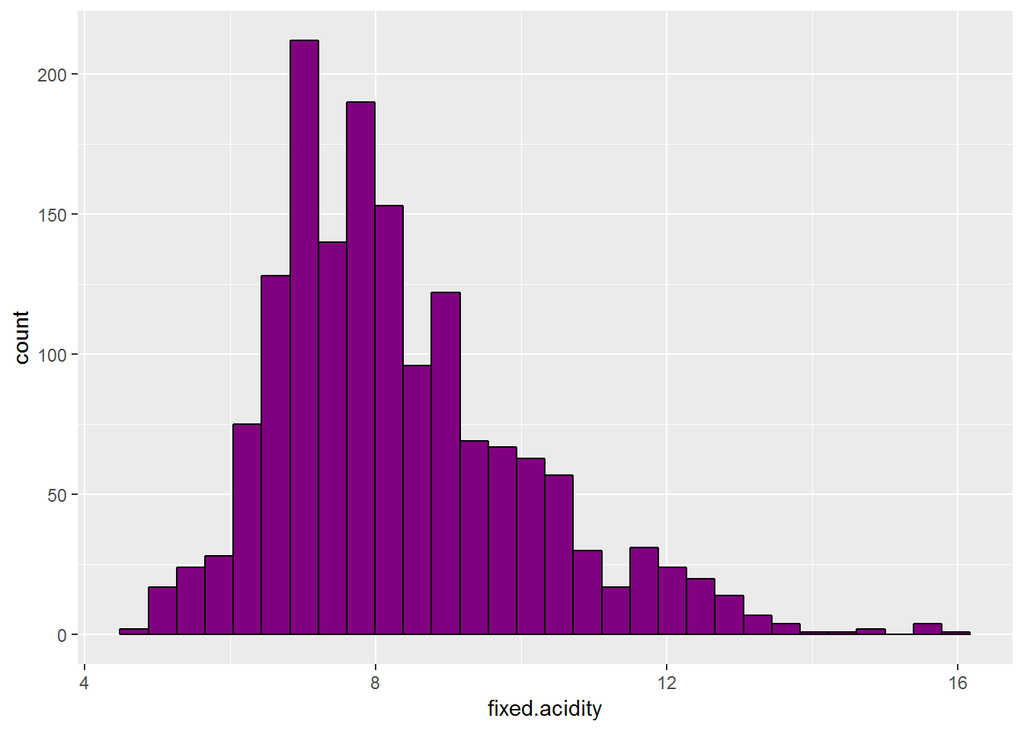

fixed.acidity shows a normal distribution with some outliers

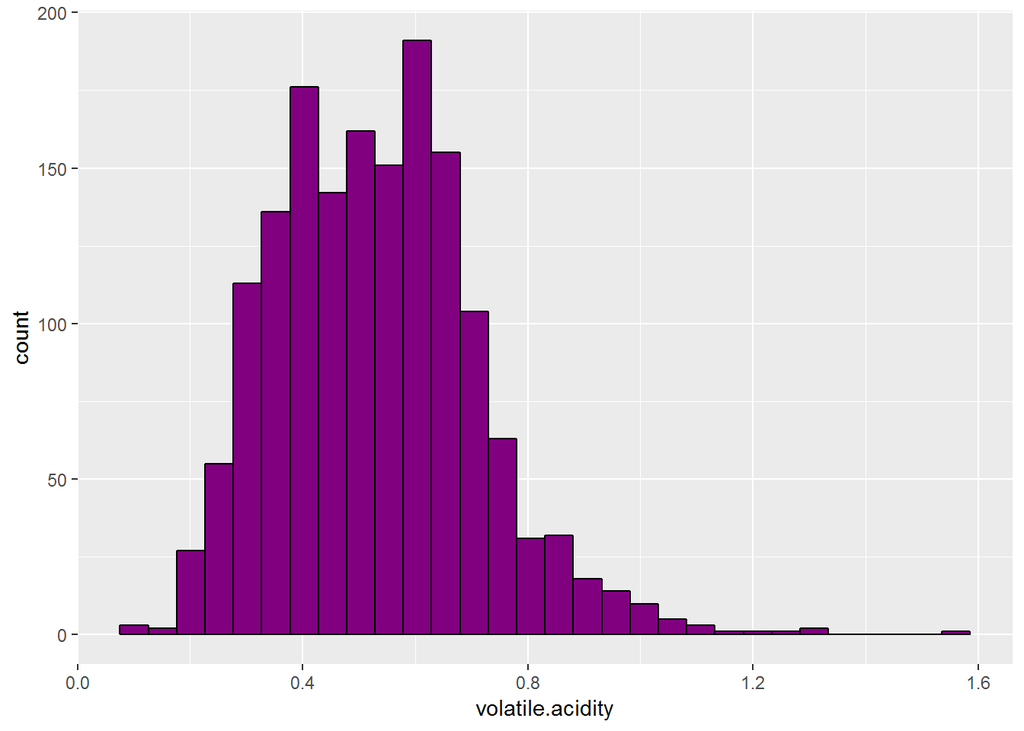

volatile.acidity shows a normal distribution with some outliers

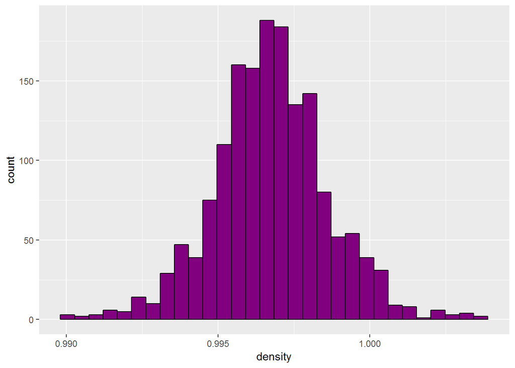

density shows a normal distribution

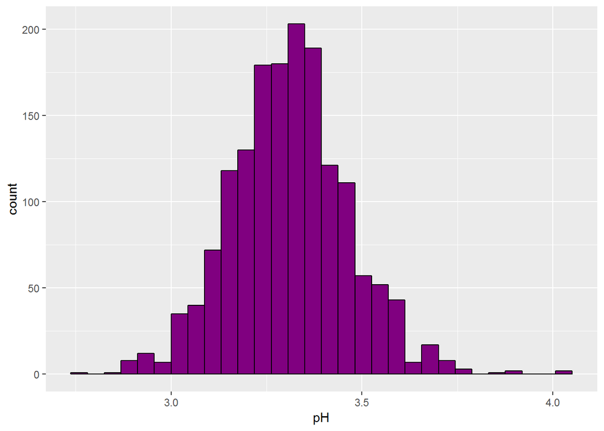

pH shows a normal distribution with some outliers on both sides

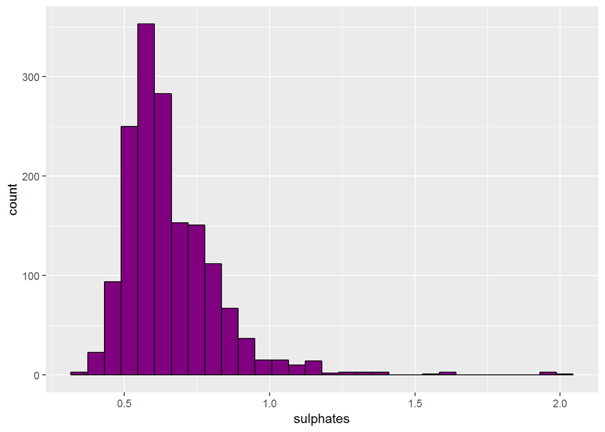

sulphates is a little right skewed and shows a near normal distribution with some outliers

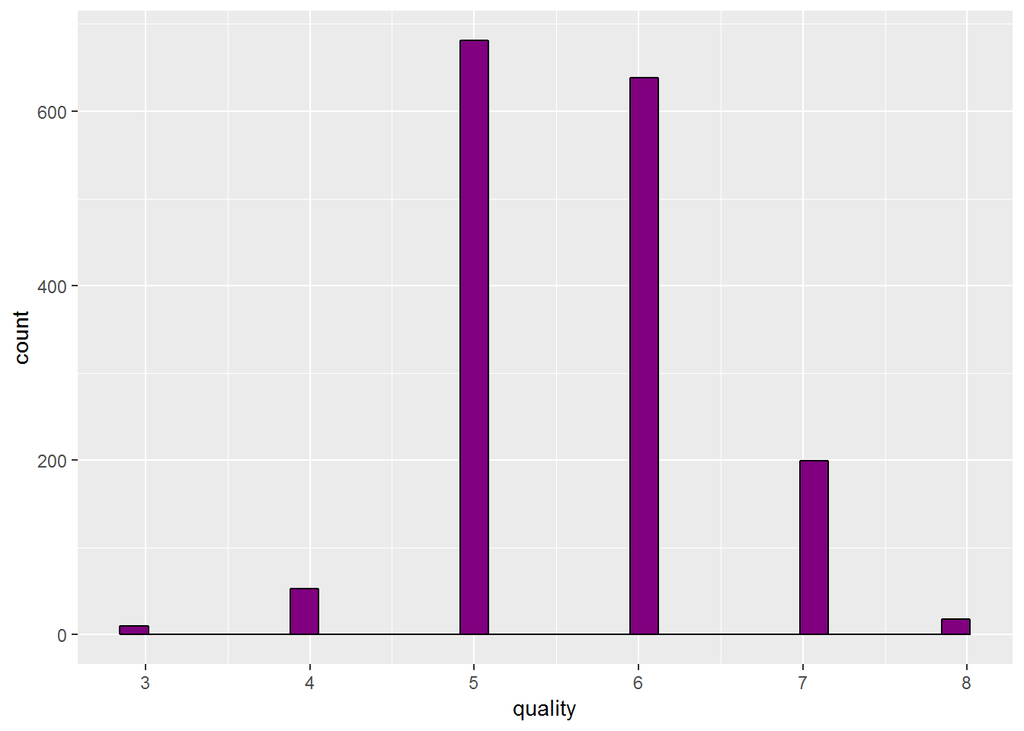

quality shows a normal distribution with most of the observations falling between 5 and 6 quality rating

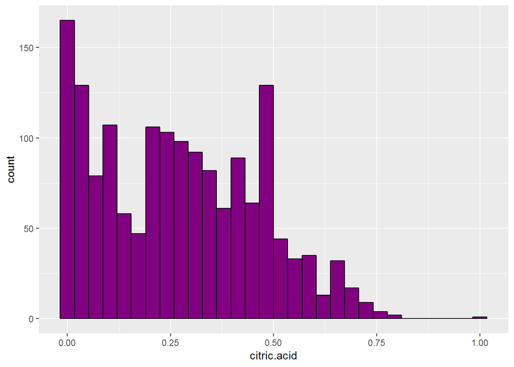

There is a pattern of peaks of higher levels of citric acid with the highest peak at 0. The histogram is also right skewed with no form of normal or near normal distribution.

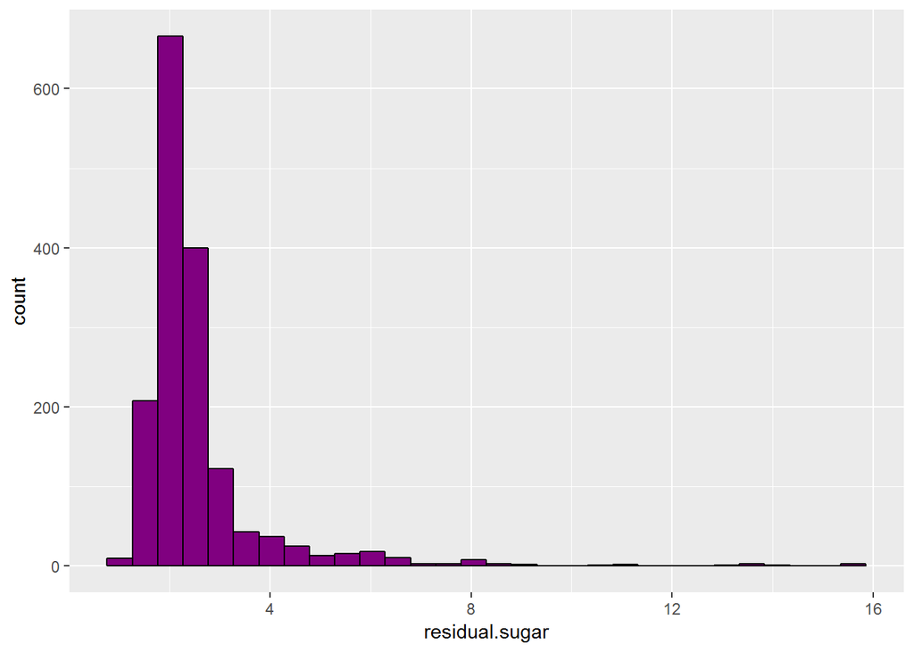

residual.sugar is right skewed with a lot of outliers

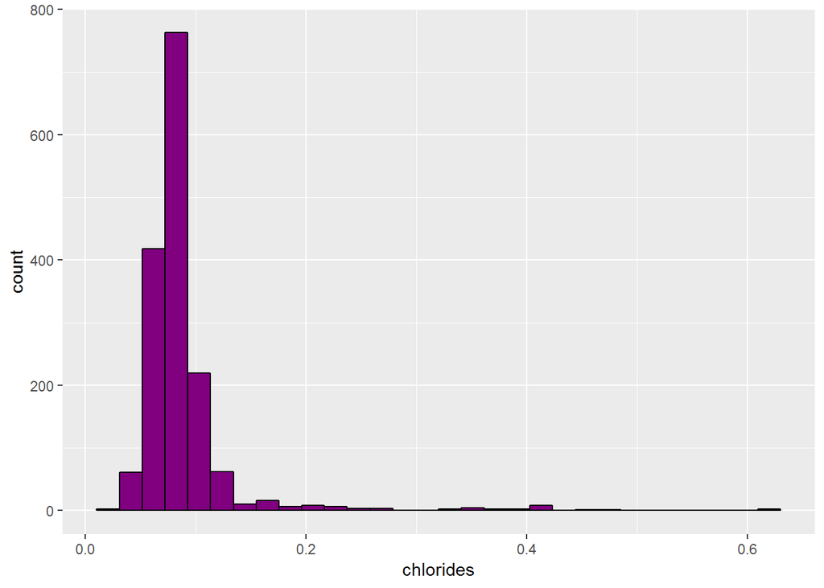

chlorides is also right skewed with a lot of outliers

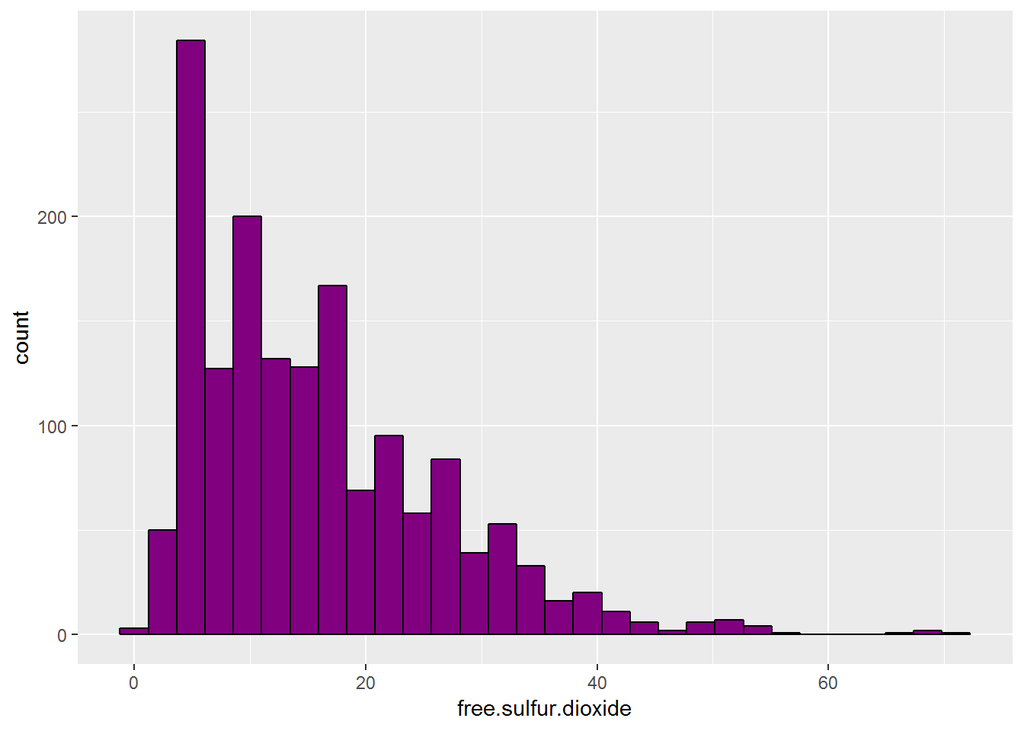

There are 6 visible peaks of higher levels of free.sulfur.dioxide. The histogram is also right skewed with no form of normal distribution and has some outliers.

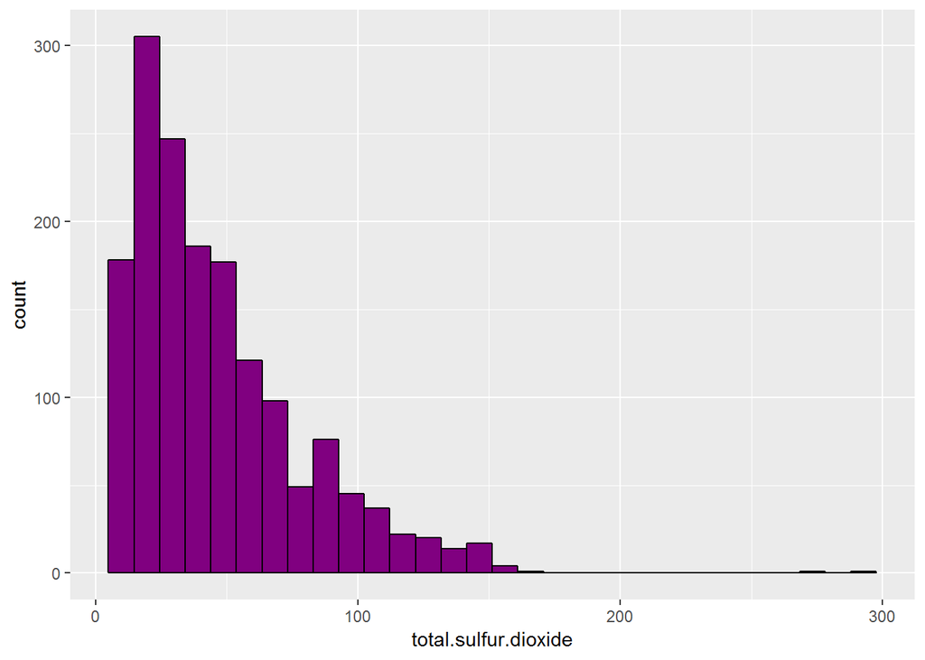

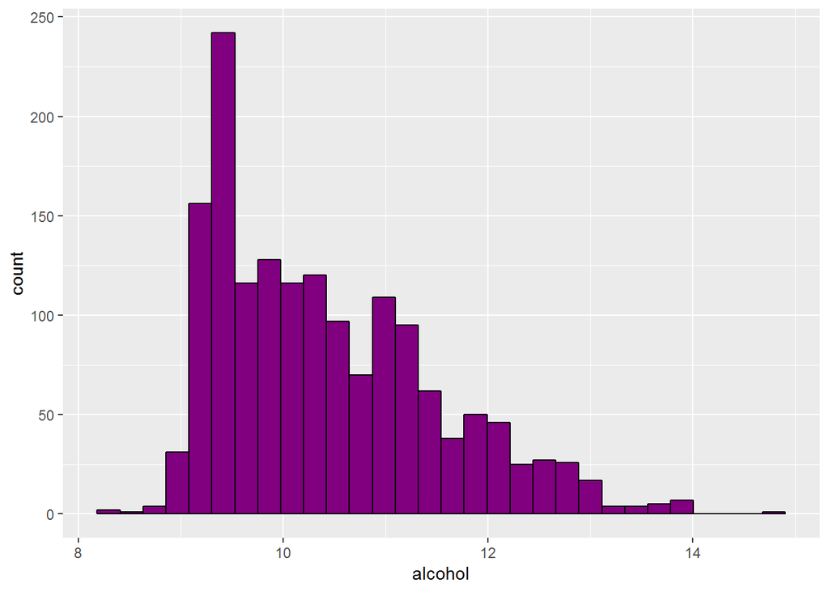

alcohol is right skewed and does not show any normal distribution

Some of these plots show a normal distribution. Others show a close normal distribution while some are not close to a normal distribution.

I will use log10 to transform the plots so as to have a better normal distribution

#### log10 transformation of frequency histograms

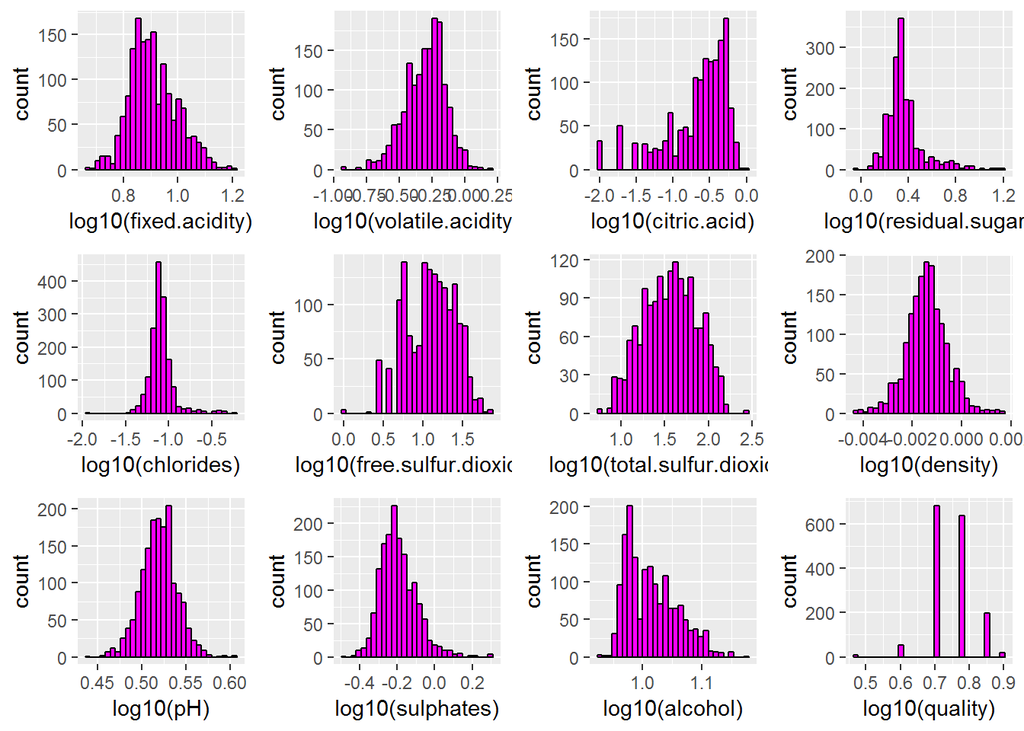

## Univariate Analysis

### About Structure of the dataset?

The variables consist of one unique identifier (x) which has an integer value, 9 input or ingredient related variables which have numeric values and 3 outcome variable of which quality has an integer value whereas pH and density have numeric values.

### Feature of interest

quality is a feature of interest to me. I will love to find out what impacts quality and also, the pH and density of wine by quality rating

### Other features in the dataset I think will help my investigation into my feature of interest?

I think features like alcohol (contribute to flavour of wine), fixed.acidity, citric.acid, and volatile.acidity(these 3 contribute to pH of wine), sulphates, chlorides, and residual.sugar (residual.sugar which contributes to the sweetness of wine), should have an impact on wine quality.

### New variable created from existing variables in the dataset

I did not create any new variable. Rather, I will transform the variable “quality” to a factor

### Of the features you investigated, were there any unusual distributions?

I used a tidy data so I did not tidy it. I transform the variables using log10-transformation to get a more normal distribution. There were a lot of outliers in the data.

# Bivariate Plots Section

I will analyse relationships between “quality”" and all variables to see how they individualy impact quality. I will look for the pH and density of red wine by quality.

## Looking for relationship between Wine Quality

#### summary of “quality”"

```
##    Min. 1st Qu.  Median    Mean 3rd Qu.    Max.
##   3.000   5.000   6.000   5.636   6.000   8.000
```

The wine score ranges from 3 (minimum score) to 8 (maximum score) for all the 1599 observations with majority of the observations scoring 5 or 6.

Without creating a new variable, I will transform the quality variable to an ordered factor based on 3 categories (Substandard, Standard, and Premium) which will hold 2 of the score groups (3-4, 5-6, and 7-8 respectively). Then run the summary of “quality”" to see the distribution of the quality score under its new label

#### Table of distribution of observation by quality

```
##
## Substandard    Standard     Premium
##          63        1319         217
```

Substandard has 63 observation, Standard wine has 1319 observations while Premium wine has 217 observations.

Using a boxplot, I want to see how the individual input variables (ingredients) impact quality and the outcome of pH and density with regards to the different quality grades

#### These are boxplots for variables with positive impact on quality

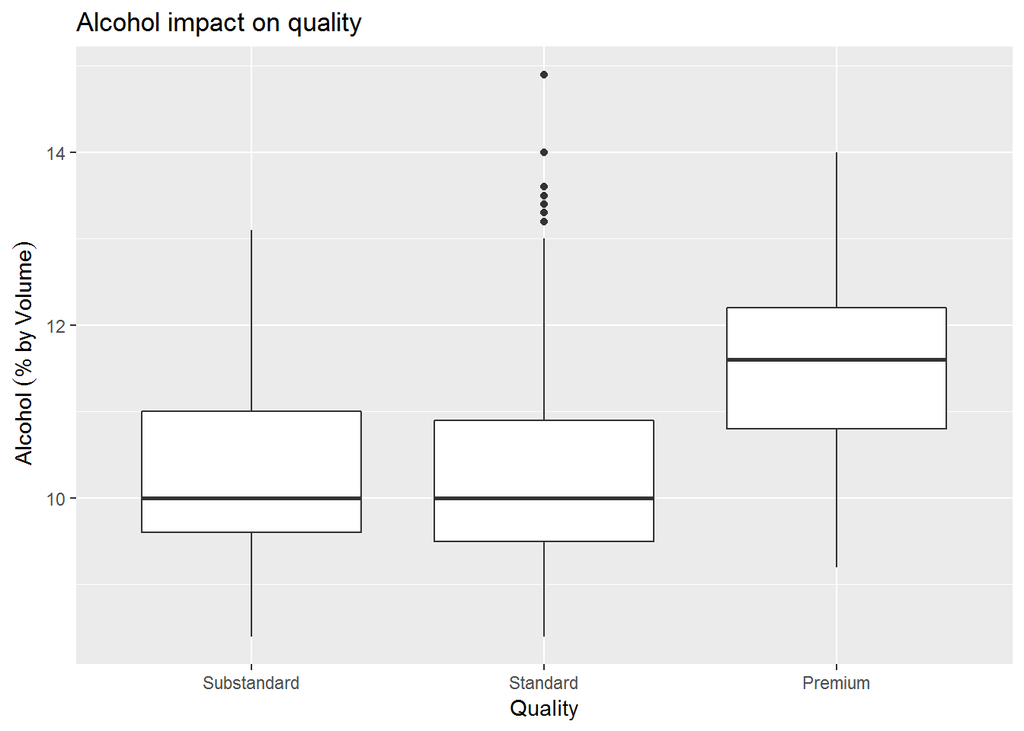

At the Standard and Substandard quality, alcohol content seem to be the same but is distinctly higher in Premium quality.

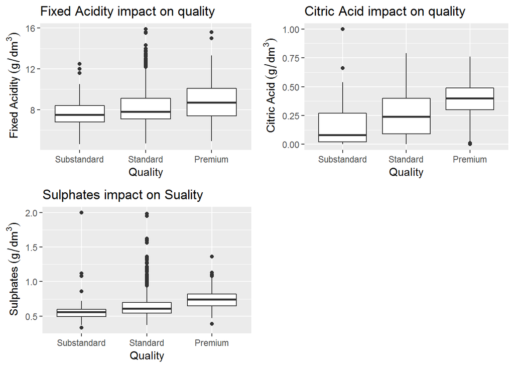

fixed.acidity, citric.acid, and sulphates show a distinct positive impact on the quality of wine. Increase in these variables result in an increase in quality.

#### These are boxplots for variables with negative or no impact on quality

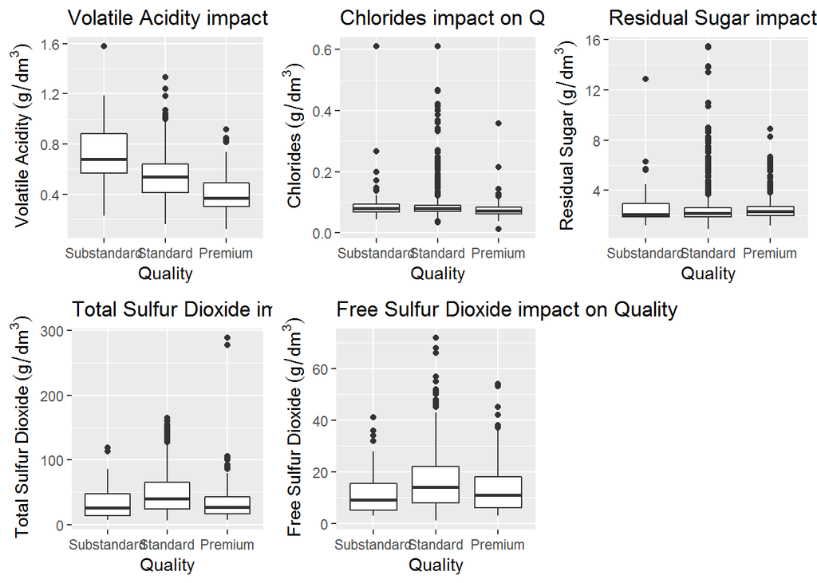

volatile.acidity shows a visible impact in quality as decrease in its content will result to increase in quality. total.sulfur.dioxide seem to have no trend on the quality of wine.

#### pH and density Boxplot by quality

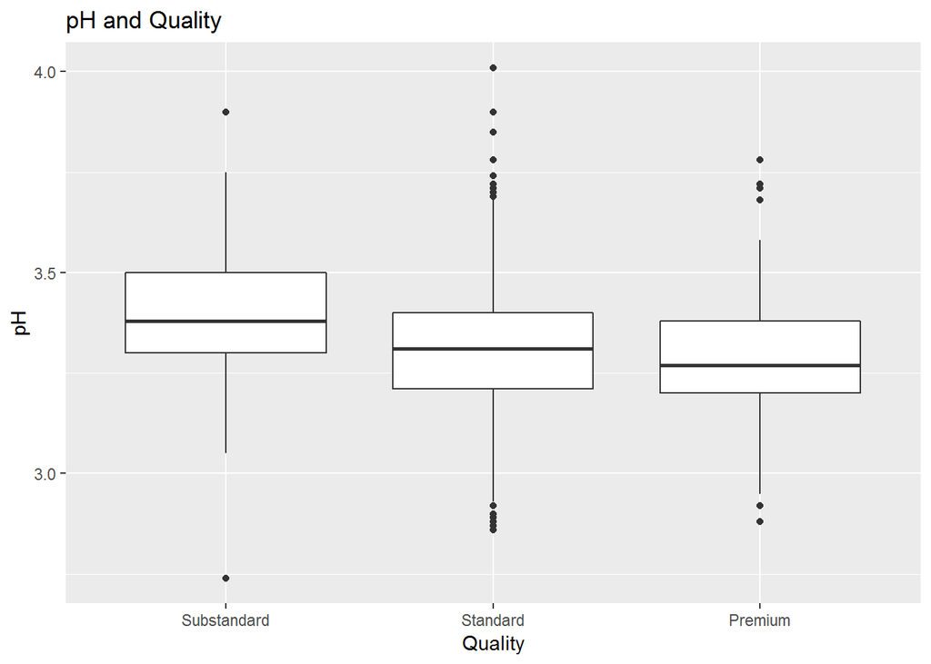

From the boxplot, Red Wine at higher quality seem to have lower pH.

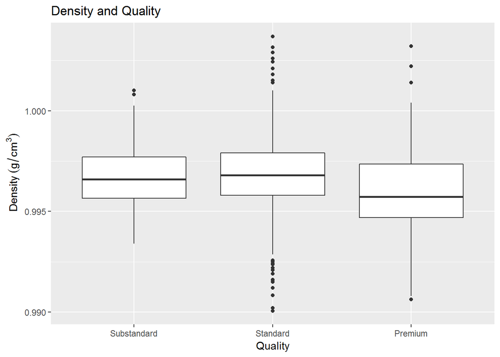

The density of Standard and Substandard wine seem to be the same while Premium wine seems to be less denser.

Substandard wine has a higher pH than Standard and Premium quality which seem to have the same pH level.

## Bivariate Relationships

I will have a further look at the relationship between these 5; alcohol, fixed.acidity, sulphates, citric.acid, and volatile.acidity which have now shown visible impacts on quality. I will randomly pair them and see the type of correlation they have with each other.

#### Scatterplots to show correlation between selected variables.

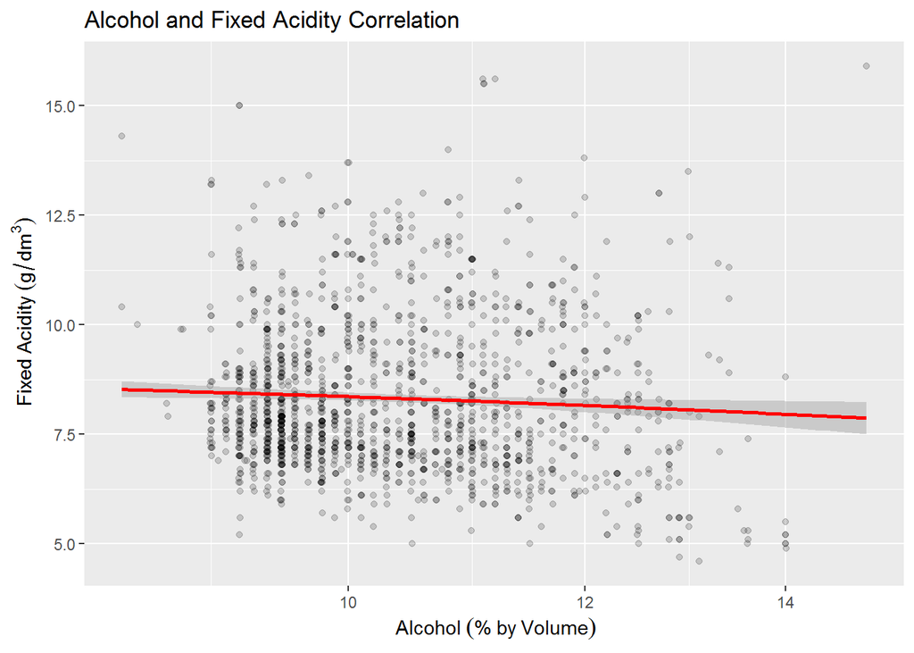

There seem to be virtually no correlation between alcohol and fixed.acidity.

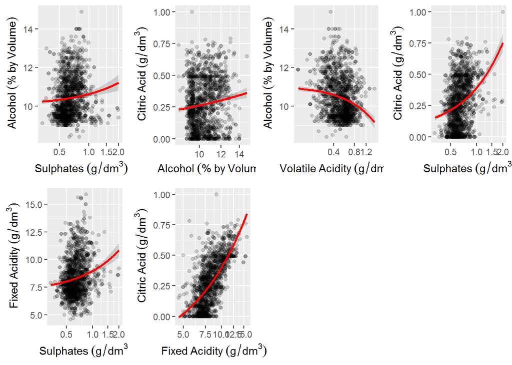

There is correlation amongst the above selected pairs.

# Bivariate Analysis

### Talk about some of the relationships you observed in this part of the investigation. How did the feature(s) of interest vary with other features in the dataset?

From the boxplots, there is a distinct increase in quality with increase in fixed.acidity, citric.acid, and sulphates. The alcohol in the Substandard and Standard wine seems to be the same but the Premium quality has more alcohol.

There is a distinct increase in quality with decrease in volatile.acidity. Premium quality has alittle les chlorides than the other qualities while Substandard quality has a little more residual.sugar than the other qualities.

Standard and Premium qualities have virtually the same pH whereas Substandard quality has a higher pH. On the other hand, Premium qualitiy red wine is a lower density than Substandard and Standard qualities which don’t seem to differ in density.

### Did you observe any interesting relationships between the other features (not the main feature(s) of interest)?

Yes. The correlation between the variables that had a positive impact on quality (their increase resulted in better quality as seen in the boxplot), had a positive correlation except for the correlation between fixed.acidity and alcohol as seen in the scatter plot.

### What was the strongest relationship you found?

The strongest correlation is between citric.acid and fixed.acidity. They have a strong positive corelation.

# Multivariate Plots Section

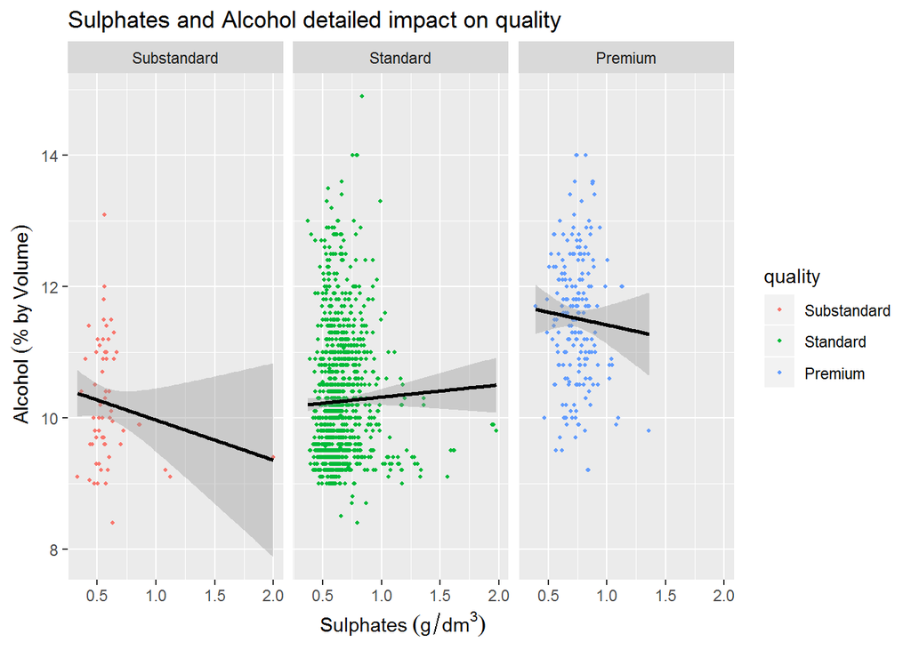

Increase in the pair sulphates and alcohol improve the quality of wine.

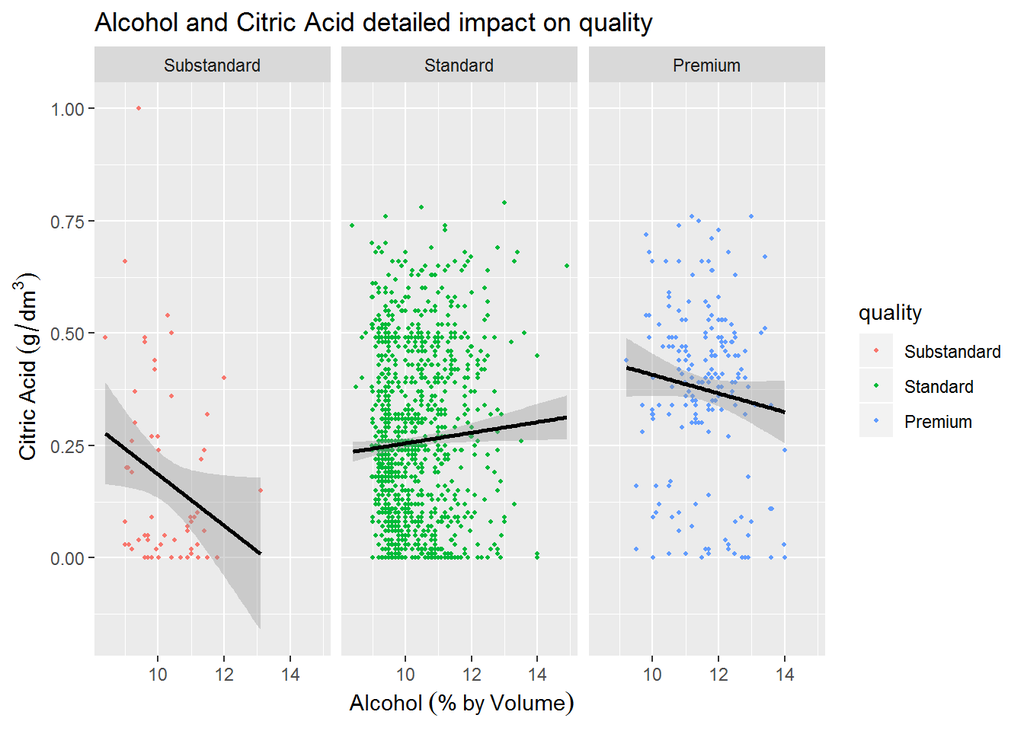

Increase in the pair alcohol and citric.acid improve the quality of wine.

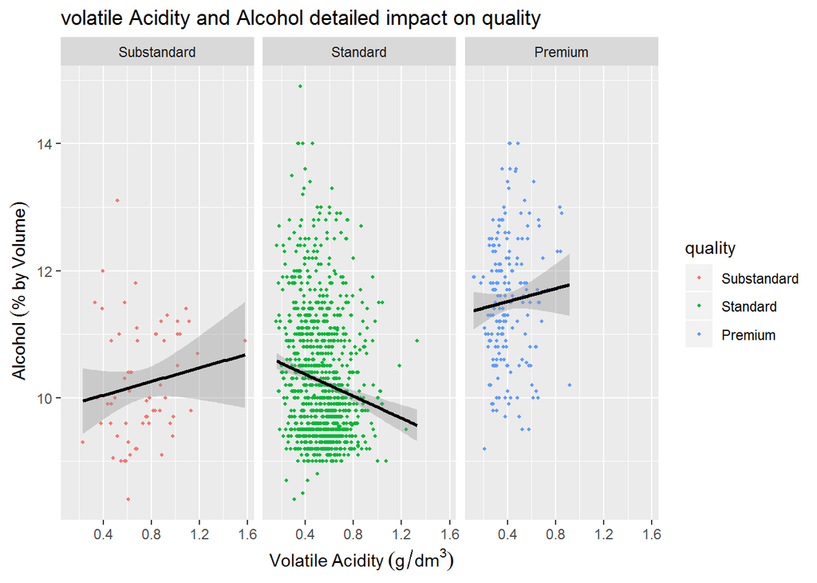

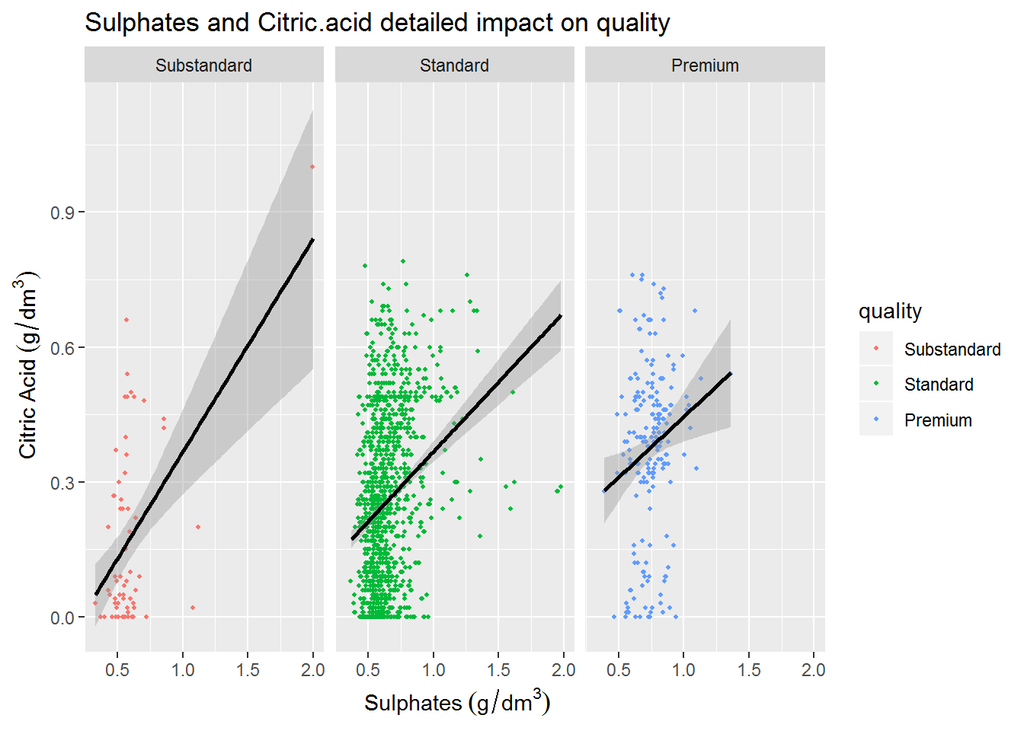

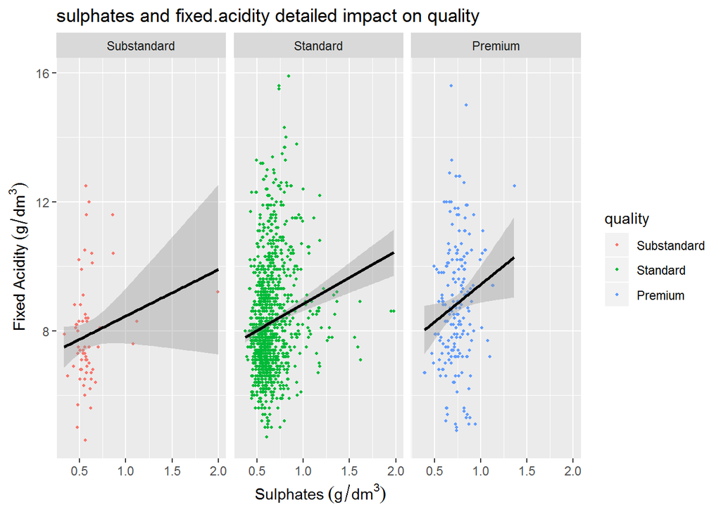

The pair sulphates and fixed.acidity does not seem to have any impact on quality.

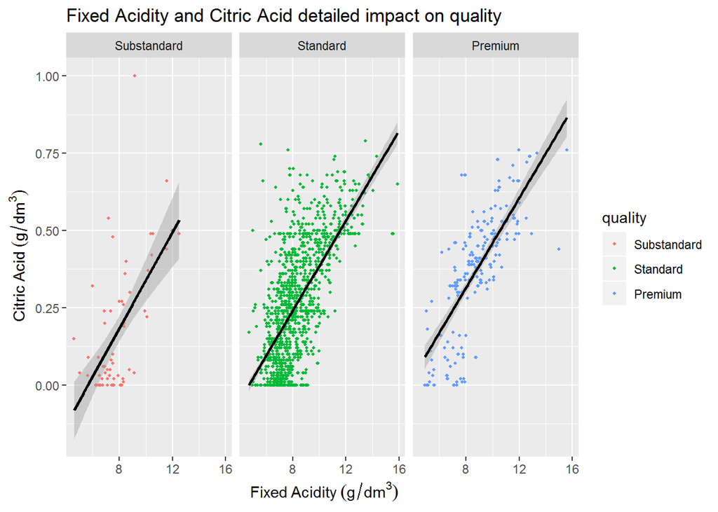

Most premium quality wine seem to have higher levels of both fixed.acidity and citric.acid.

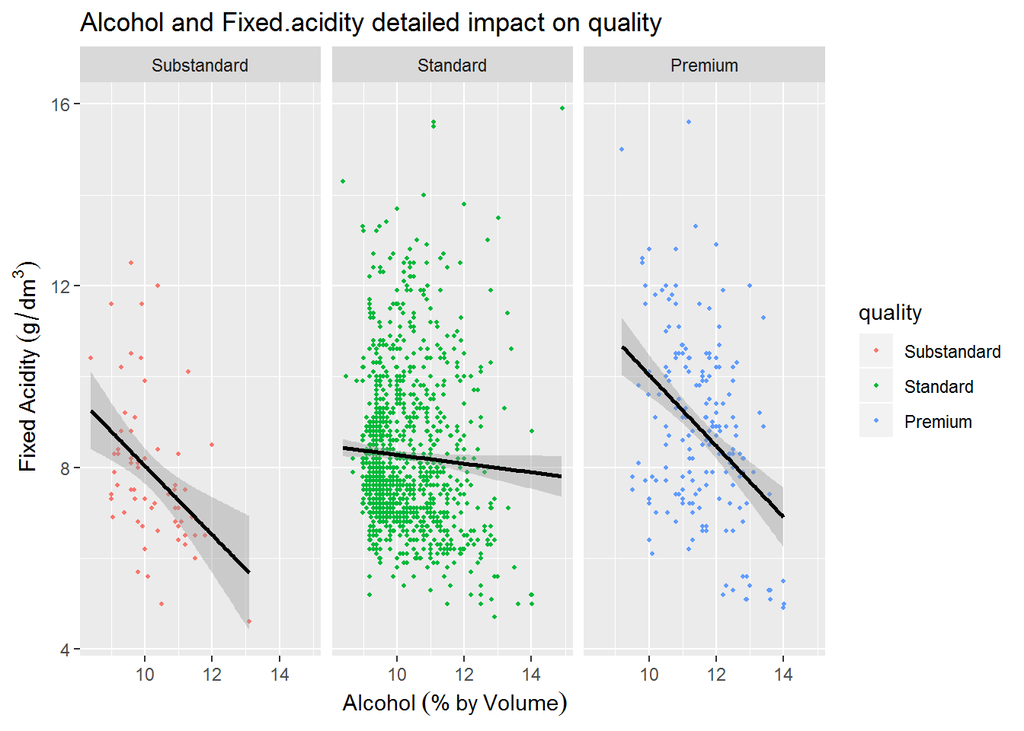

The pair alcohol and fixed.acidity, seem to improve the quality of wine only at premium quality.

# Multivariate Analysis

### Talk about some of the relationships you observed in this part of the investigation. Were there features that strengthened each other in terms of looking at your feature(s) of interest?

Higher citric.acid and Higher alcohol combined produce better wines. High alcohol contents and high sulphate concentrations combined produce better wines. Higher Alcohol combined with lover volatile.acidity produces better wine.

# Final Plots and Summary

### Plot One

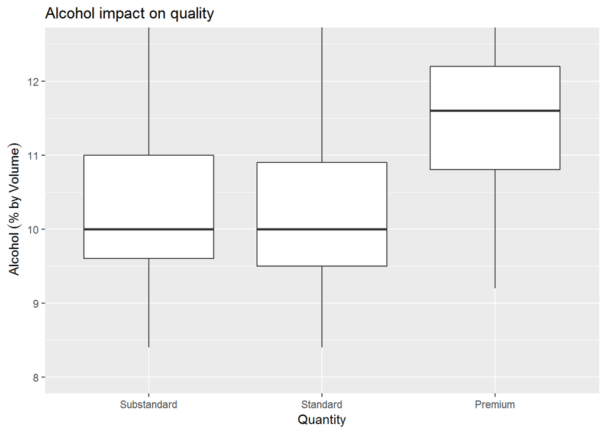

### Description One

Most Premium wine have more alcohol than substandard and standard wine when consideration is given only to the impact of alcohol on quality. About 75% of Premium wine have a distinct high level of alcohol. On the other hand, one cannot seperate a substandard wine from a standard wine just by their alcohol content and only 25% of substandard and standard wine have high alcohol content.

### Plot Two

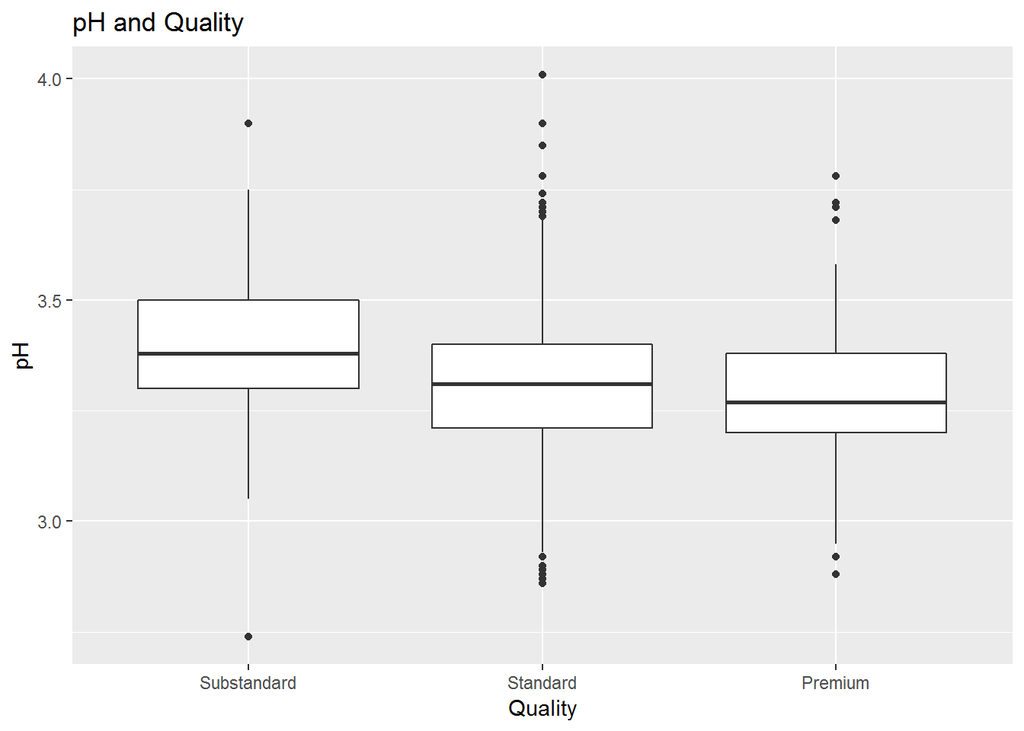

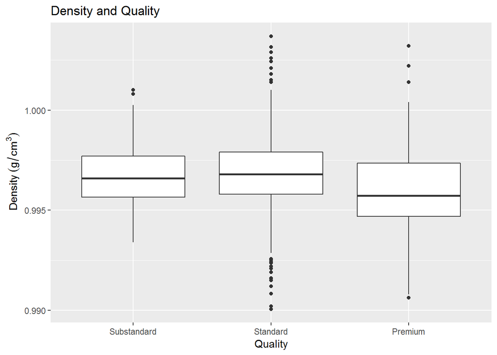

### Description Two

Standard and Premium qualities have virtually the same pH whereas Substandard quality has a higher pH. That is to say that Premium and Standard qualities are more acidic than Substandard qualities. On the other hand, Premium qualitiy red wine has less density than Substandard and Standard qualities which don’t seem to differ in density.  
### Plot Three

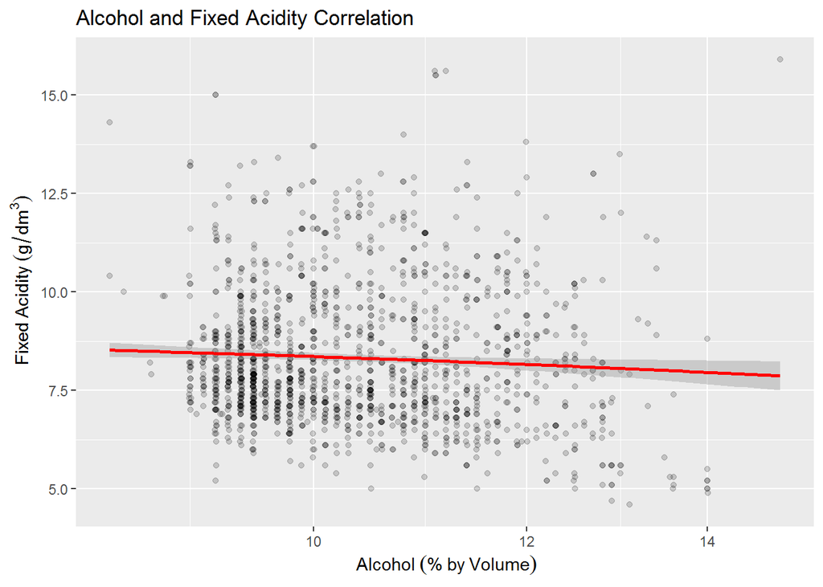

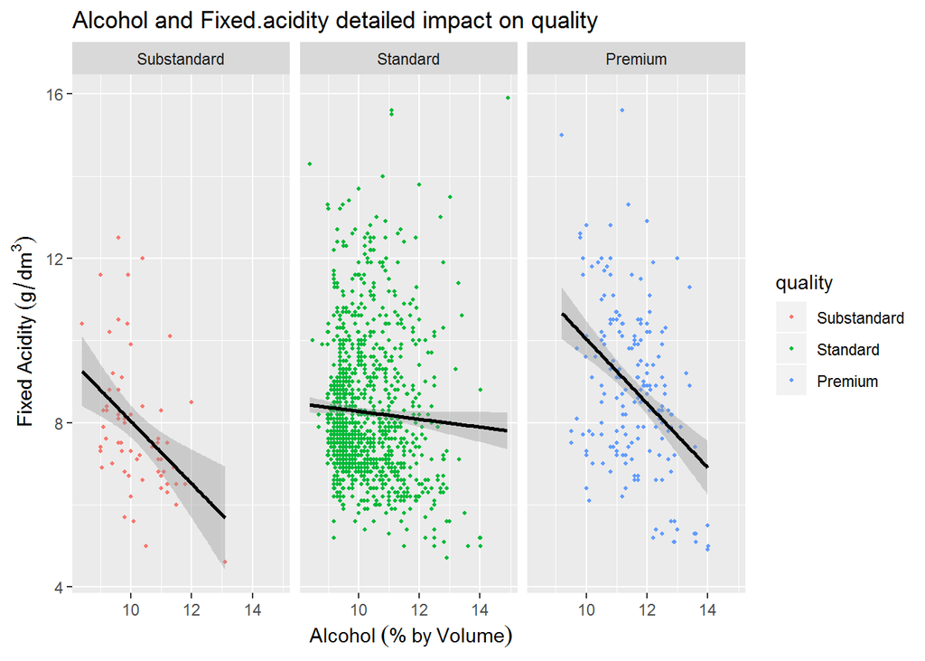

### Description Three

The relationship between alcohol and fixed.acidity seem to almost be neutral. Increasing the alcohol results in a small or no decrease in fixed.acidity as seen in the bivariate relationship plot above. But seperating this relationship by the wine quality doesn’t give the same result. I found that there is a strong negative correlation of alcohol and fixed.acidity in the substandard and premium wine. The almost neutral correlation that was seen before is now only visible with the standard wine.

# Reflection

A total of 63 (about 4%) observations were rated as Substandard (scored 3 or 4). 1319 (about 82%) observations rated as Standard (scored 5 or 6). While 217 observations (about 14%) rated as Premium (score of 7 or 8). There is a lot of observations on Standard wine and very few observations on premium and even fewer observations on substandard win. This might cause some bias in correlation and might explain why the correlation between alcohol and fixed.acidity was so strong in the substandard and premium quality which had relatively few observation as compared to the near zero correlation that I found in standard quality with so many observations. This was a big issue for me as I had to do an redo most of my correlations because I kept doubting the results.

Most Premium red wine have high alcohol, citric acid, fixed acid (acid that is not volatile) and low volatile.acidity. At the same time, Premium red wine has a lower density then Standard and substandard red wine with Standard and Premium wine haven a lower pH than Substandard wine.

I think for future analysis, it will be good to give the names of the actual acids used like malic acid, tartaric acid and the flavors used if any.

I used this website for information about the datset https://s3.amazonaws.com/udacity-hosted-downloads/ud651/wineQualityInfo.txt